# Introdução ao R Markdown

Aprendendo R Markdown na prática

Viktor Chagas, Universidade Federal Fluminense [^1]

Abstract

Este é um exemplo de relatório de final de curso a ser entregue para a disciplina de Introdução à Análise de Pesquisa Quantitativa, semestre letivo 2020.2, na graduação em Estudos de Mídia.

# R Markdown

O R Markdown é uma sintaxe simples, baseada simultaneamente na linguagem de marcação Markdown e na linguagem estatística R. Os documentos escritos em R Markdown podem gerar arquivos em diversos formatos, entre eles, uma página HTML, um PDF, um documento MS Word ou até uma apresentação de slides.

Para criar um novo documento em R Markdown, abra seu *R Studio*, e, em seguida, instale os dois pacotes abaixo, caso ainda não os tenha instalados:

```
install.packages("knitr")
install.packages("rmarkdown")
```

Após a instalação, acesse o menu *File*, e, depois, a opção *New File* e *R Markdown*. Selecione o formato *Documento*, preencha o título e o nome do autor, e marque o output desejado, se HTML, PDF ou documento Word. Um novo arquivo com a extensão *.Rmd* será aberto.

Os documentos escritos em R Markdown devem obedecer a uma sintaxe específica. Você pode obter um resumo dessa sintaxe nesta *cheatsheet*: https://www.rstudio.com/wp-content/uploads/2015/02/rmarkdown-cheatsheet.pdf. As principais marcações são as que seguem:

## Formatação de texto

```
*itálico*   **negrito**

_itálico_   __negrito__
```

*itálico* **negrito**

## Headers

```
# Exemplo de Cabeçalho 1
## Exemplo de Cabeçalho 2
### Exemplo de Cabeçalho 3
```

# Exemplo de Cabeçalho 1

## Exemplo de Cabeçalho 2

### Exemplo de Cabeçalho 3

## Listas ordenadas e não-ordenadas

```
* Lista Não-Ordenada Item 1
* Lista Não-Ordenada Item 2
* Lista Não-Ordenada Item 3

1. Lista Ordenada Item 1
2. Lista Ordenada Item 2
3. Lista Ordenada Item 3
```

- Lista Não-Ordenada
1. Lista Ordenada

## Outras formatações

```
[Texto linkado](http://exemplo.com)

> Citação

Sobrescrito^2^

~~strikethrough~~
```

[link para o gitHUB](http://github.com)

> Citação

sobrescrito<sup>2</sup>

tachado

## Estrutura do R Markdown

O código de um documento R Markdown geralmente possui um cabeçalho de metadados, chamado de *YAML Header*. Neste cabeçalho, você pode inserir informações como o título do documento, o nome do autor, a data e outras mais.

Além do cabeçalho YAML, os documentos R Markdown se estruturam a partir de uma combinação entre texto simples (*body text*) e blocos de código (*code chunks*). Os *code chunks* são pequenos blocos de código em linguagem R utilizados para apresentar comandos ou resultados de funções no seu relatório, como gráficos e mapas.

[figure not shown]

Layout de um documento R Markdown

## Sintaxe

Para inserir um *code chunk* em seu documento R Markdown, basta você utilizar o cabeçalho `` ```{ r codechunk} ``, digitar `seu código`, e encerrar com o rodapé `` ``` ``

Por exemplo, se digitarmos `` ```{r pinguins} ``, seguido de `summary(penguins)` e encerrarmos com `` ``` ``, teremos o seguinte resultado:

```r
summary(penguins)
```

```
##       species          island    bill_length_mm  bill_depth_mm
##  Adelie   :152   Biscoe   :168   Min.   :32.10   Min.   :13.10
##  Chinstrap: 68   Dream    :124   1st Qu.:39.23   1st Qu.:15.60
##  Gentoo   :124   Torgersen: 52   Median :44.45   Median :17.30
##                                  Mean   :43.92   Mean   :17.15
##                                  3rd Qu.:48.50   3rd Qu.:18.70
##                                  Max.   :59.60   Max.   :21.50
##                                  NA's   :2       NA's   :2
##  flipper_length_mm  body_mass_g       sex           year
##  Min.   :172.0     Min.   :2700   female:165   Min.   :2007
##  1st Qu.:190.0     1st Qu.:3550   male  :168   1st Qu.:2007
##  Median :197.0     Median :4050   NA's  : 11   Median :2008
##  Mean   :200.9     Mean   :4202                Mean   :2008
##  3rd Qu.:213.0     3rd Qu.:4750                3rd Qu.:2009
##  Max.   :231.0     Max.   :6300                Max.   :2009
##  NA's   :2         NA's   :2
```

E, se quisermos desenhar um gráfico com esses dados, basta inserir o código referente a este gráfico no chunk, como abaixo:

`` ```{r grafico} ``

`` ``` ``

Veja só como ele será apresentado:

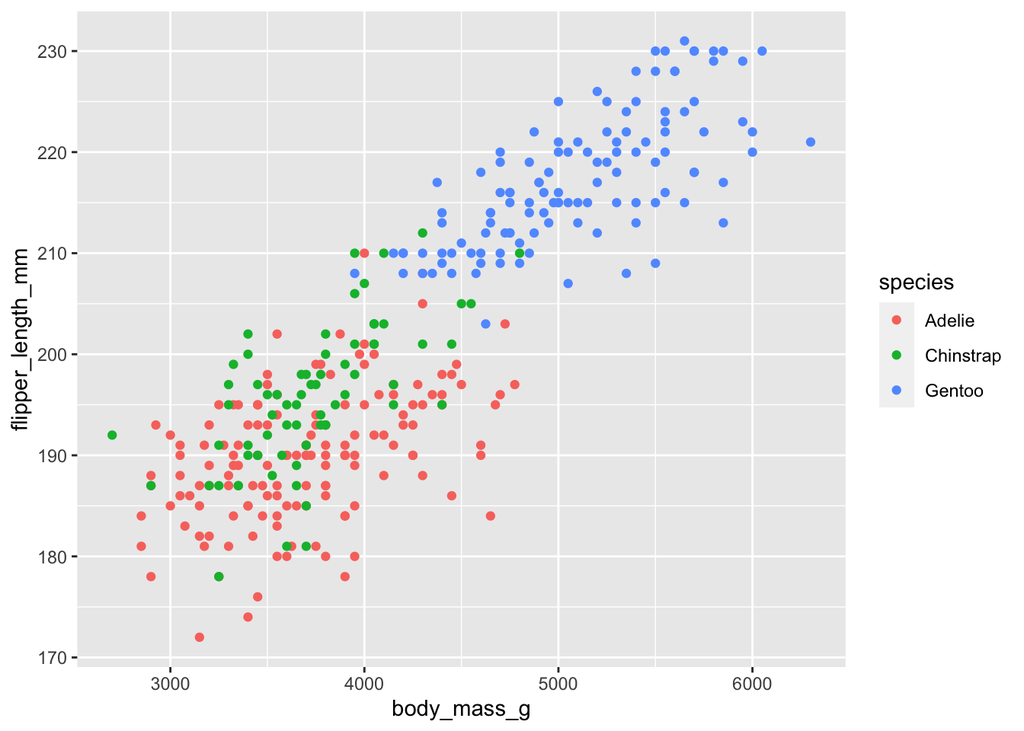

```r
penguins %>%
  tidyr::drop_na() %>%
  ggplot() + geom_point(aes(x = body_mass_g, y = flipper_length_mm,
                            color = species))
```

[output not shown]

Outro uso importante diz respeito ao parâmetro `echo = FALSE`, que você pode utilizar no cabeçalho de seu *code chunk* para prevenir a impressão do código R responsável por plotar gráficos e dados. Assim, você oculta o código e imprime apenas o gráfico ou os dados, como abaixo.

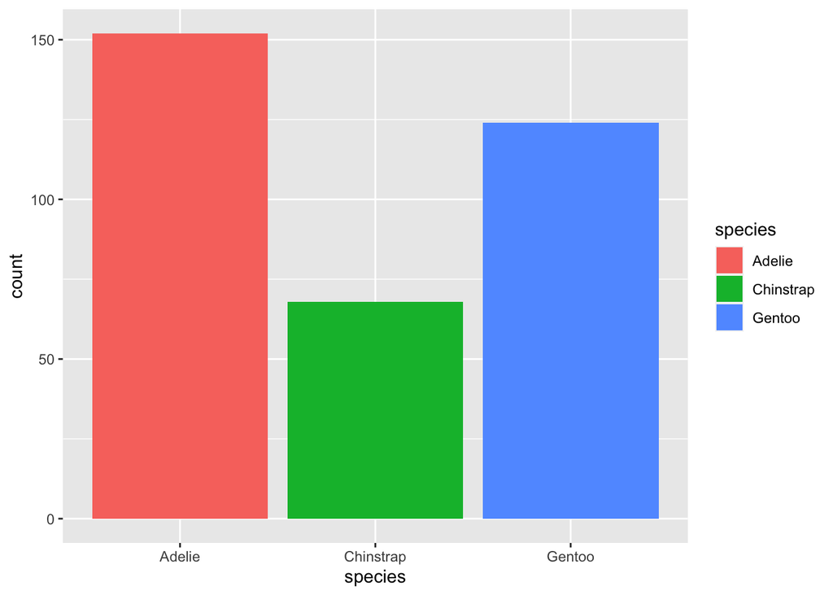

## Conversão

Para finalizar o seu documento R Markdown, é preciso gerar o *output*. Você pode fazer isso clicando no botão **Knit** e selecionando, p.ex., **Knit to PDF**. O *output* será aberto em uma nova janela.

[^1]: Professor e pesquisador do Programa de Pós-Graduação em Comunicação da Universidade Federal Fluminense. Doutor em História, Política e Bens Culturais pelo Centro de Pesquisa e Documentação de História Contemporânea do Brasil da Fundação Getulio Vargas. viktor@midia.uff.br